# Coloração de Grafos

## Introdução

## Descrição do Problema

Seja um grafo \(G=(V,E)\) com \(n\) vértices \(\in V\) e \(m\) arestas \(\in E\). O problema de coloração de grafos consiste em atribuir a cada vértice \(v \in V\) um inteiro \(c(v) \in \{1,2,..,k\}\) em que:

- \(c(v) \neq c(u) \,\forall\, \{v,u\} \in E\).
- \(k\) é mínimo.

Um exemplo:

[figure not shown]

### Observações:

- Supõe-se que o grafo \(G\) é **conexo**.
- \(G\) é **simples**.
- Serão apresentados problemas relacionados à **coloração dos vértices**.

É importante tratar o problema de coloração de grafos como um tipo de **problema de partição dos vértices** ,a partir de restrições (presença de aresta), no qual uma solução \(S\) é representada por \(k\) grupos:  
\(S= \{S_1,S_2,...,S_k\}\)

## Aplicações:

- Colorir mapas;
- Resolver jogos *Sudoku*;
- Construção de Horários (para aulas, eventos, etc);
- Construção de escalas (para taxis, ônibus, etc);
- Alocação de assentos em eventos;
- Verificar se um grafo é bipartido;
- Entre outros problemas que podem ser abordados como problemas de coloração de grafos.

## Definições

- Uma coloração é **possível** se, e somente se, todos os vértices \(v\) estão associados a uma cor e vértices adjacentes não tenham a mesma cor.
- O **número cromático** de um grafo é \(\chi(G)=k\) mínimo. Uma coloração **possível** de \(G\) usando exatamente \(\chi(G)\) cores é considerada **ótima**.
- Uma **classe de cor** é um conjunto \(\{v \in V:c(v)=i\}\).
- Um **conjunto independente** é um subconjunto de vértices \(I\subseteq V\) tal que \(\forall \, u,v \in I, \{u,v\}\notin E\).
- Um **clique** é um subconjunto de vértices \(C \subseteq V\) tal que \(\forall \, u,v \in C, \{u,v\}\in E\).
- A **vizinhança** de um vértice \(v\) é dada por \(\Gamma(v)=\{u \in V: \{u,v\}\in E\}\).
- O **grau** de um vértice \(v\) é \(deg(v)=||\Gamma(v)||\)

## Complexidade do Problema

Em geral, encontrar uma coloração ótima para um grafo \(G\) é um problema NP-difícil.

\(\Rightarrow\) **Solução:** Algoritmos Construtivos, Heurísticos ou Meta-Heurísticos.

- Esses algoritmos encontrarão **soluções subótimas**.
- Dependendo do grafo \(G\) e do algoritmo escolhido a solução pode ser boa ou ruim.
- Ainda assim, para determinados tipos de grafos, é fácil encontrar uma solução ótima.

## Grafos Completos

Dado um grafo completo com \(n\) vértices, \(K_n\):

- \(\forall \,\, u,v \in V(K_n), \{u,v\} \in E(K_n)\).
- É fácil ver que \(\chi(K_n)=n\)

Coloração ótima dos grafos \(K_1, K_2, K_3, K_4 \,e\, K_5\) respectivamente:

[figure not shown]

### R: igraph package - Grafos Completos \(\Rightarrow \chi(K_n)=n\)

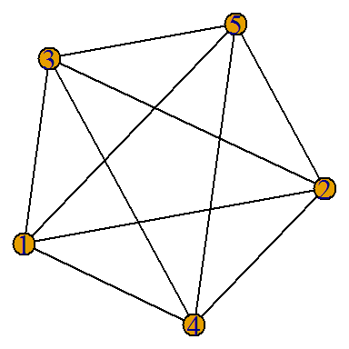

```r
g <- make_full_graph(5)
```

```r
length(max_cliques(g)[[1]]) == length(V(g)) #O grafo é completo?
```

```
## [1] TRUE
```

```r
length(V(g)) #Nº cromático
```

```
## [1] 5
```

## Grafos Bipartidos

Dado um grafo bipartido \(G=(V_1,V_2,E)\):

- Se \(u,v \in V_i \,\,\forall\,\, i=1,2\); então \(\{u,v\} \notin E\)
- É fácil ver que \(\chi(G)=2\)

Coloração ótima para alguns exemplos de grafos bipartidos:

[figure not shown]

\(\Rightarrow\) Se \(\chi(G)=2\), o grafo \(G\) é Bipartido.

### R: igraph package - Grafos Bipartidos \(\Rightarrow \chi(G)=2\)

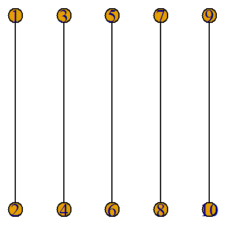

```r
g <- make_bipartite_graph( rep(0:1,length=10), c(1:10))
```

```r
bipartite.mapping(g)$res #Grafo é bipartido?
```

```
## [1] TRUE
```

## Grafos Cíclicos

Dado um grafo cíclico com \(n\geq3\) vértices, \(C_n\):

- \(V(C_n)=\{v_1,...,v_n\}\)
- \(E(C_n)=\{\{v_1,v_2\},\{v_2,v_3\},...,\{v_{n-1},v_n\},\{v_n,v_1\}\}\)
- É fácil ver que se \(n\) é par: \(\chi(C_n)=2\); se \(n\) é ímpar: \(\chi(C_n)=3\)

Coloração ótima para os grafos \(C_3,C_4,C_8 \,e\, C_9\) respectivamente:

[figure not shown]

### R: igraph package - Grafos Cíclicos \(\Rightarrow \chi(C_{par})=2\) ; \(\chi(C_{impar})=3\)

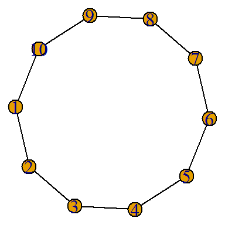

```r
g <- graph.ring(10)
```

```r
girth(g)$girth == length(V(g)) #Grafo é cíclico?
```

```
## [1] TRUE
```

```r
length(V(g)) #Se par: Nº cromático = 2, Se ímpar: Nº cromático = 3
```

```
## [1] 10
```

## Algoritmos Construtivos

## Algoritmo GREEDY

Toma-se um vértice por vez a partir de uma sequência e atribui-se a primeira *cor* disponível a ele.  
Passo a passo com sequência = \(v_1, v_2,..., v_8\):

[figure not shown]

### R: igraph package - Algoritmo GREEDY

```r
library(igraph)

vertex.color.greedy <- function(g, seq=V(g)){
    grps <- list()
    for(i in seq){
      if(length(grps)==0){grps[[1]]<-i}else{
        for(j in 1:length(grps)){
          if(sum(grps[[j]]%in%neighbors(g,i))==0){grps[[j]]<- c(grps[[j]],i);break}
        }
        if(sum(i%in%unlist(grps))==0){grps[[(length(grps)+1)]] <- i}
      }
    }
  grps2 <- list(no._de_grupos=length(grps),grupos=grps)
  return(grps2)
}
```

- O Algoritmo *GREEDY* produz sempre e rapidamente uma solução **possível**. No entanto pode ser pobre quanto ao número de grupos formados em relação a \(\chi(G)\).

### Teorema:

Seja \(S\) uma solução **possível** para \(G\). Se cada classe de cor \(S_i \in S\) é considerada por vez no algoritmo *GREEDY*, a solução resultante \(S'\) será tal que \(|S'| \leq |S|\).

**Exemplo:**

- Sequência: \(S=\{S_1,S_2,S_3,S_4\}=\{\{v_1,v_5,v_6\},\{v_2,v_3,v_8\},\{v_4\},\{v_7\}\}\).

No pior dos casos:  
\(S'_1=\{v_1,v_5,v_6\}\)  
\(S'_2=\{v_2,v_3,v_8\}\)  
\(S'_3=\{v_4\}\)  
\(S'_4=\{v_7\}\)  
\(|S'|=|S|\)

\(\Rightarrow\) GREEDY pode obter solução ótima.

### R: igraph package - Algoritmo GREEDY [Versão Alternativa]

```r
vertex.color.greedy.2 <- function(g, seq=V(g),times=1){
  n=0
  while(n<times){
    grps <- list()
    for(i in seq){
      if(length(grps)==0){grps[[1]]<-i}else{
        for(j in 1:length(grps)){
          if(sum(grps[[j]]%in%neighbors(g,i))==0){grps[[j]]<- c(grps[[j]],i);break}
        }
        if(sum(i%in%unlist(grps))==0){grps[[(length(grps)+1)]] <- i}
      }
    }
    for(i in 1:length(grps)){
      if(length(grps[[i]])>1){grps[[i]] <- sample(grps[[i]])}
    }
    seq <- unlist(sample(grps),use.names = F)
    n=n+1
  }

  grps2 <- list(no._de_grupos=length(grps),grupos=grps)
  return(grps2)
}
```

## Pacote 'tmaptools': GREEDY

```
##  [1] 1 4 1 2 2 2 3 1 2 4
```

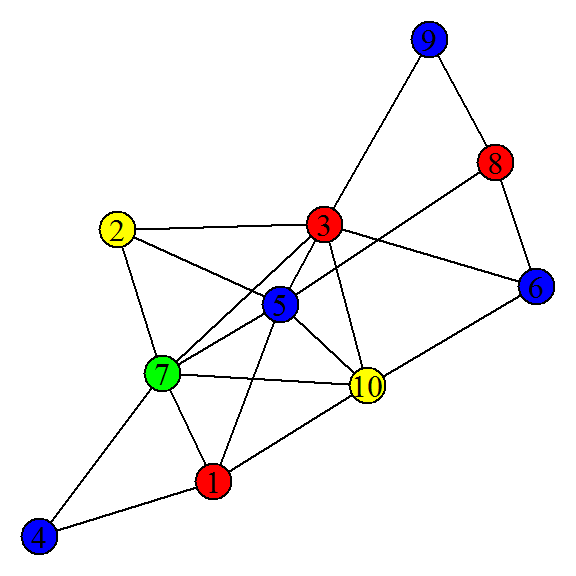

```r
g <- erdos.renyi.game(10, 20, "gnm")
g1 <- as_adj_list(g)
library(tmaptools)
tmap.col <- map_coloring(g1, algorithm = "greedy", minimize=TRUE) ; tmap.col
```

## Pacote 'RBGL': GREEDY

```r
g <- erdos.renyi.game(15, 30, "gnm")
class(g)
```

```
## [1] "igraph"
```

```r
library("BiocManager")
BiocManager::install("RBGL", version = "3.8")
```

```r
g1 <- graph::graphAM(get.adjacency(g, type="both", sparse = F),edgemode = "undirected")
class(g1)
```

```
## [1] "graphAM"
## attr(,"package")
## [1] "graph"
```

## Pacote 'RBGL': GREEDY

```r
RBGL::sequential.vertex.coloring(g1)
```

```
## $`no. of colors needed`
## [1] 4
##
## $`colors of nodes`
##  n1  n2  n3  n4  n5  n6  n7  n8  n9 n10 n11 n12 n13 n14 n15
##   0   1   0   1   2   0   1   1   2   3   0   0   0   1   3
```

```r
vertex.color.greedy(g)$grupos
```

```
## [[1]]
## [1]  1  3  6 11 12 13
##
## [[2]]
## [1]  2  4  7  8 14
##
## [[3]]
## [1] 5 9
##
## [[4]]
## [1] 10 15
```

## Limites para \(\chi (G)\)

## Limite Inferior

- Se o grafo \(G\) possui subgrafo completo *(clique)* \(K_h\), logo \(\chi(G) \geq h\).

[figure not shown]

## Limite Superior

- Se o grafo \(G\) tem grau máximo \(\Delta(G)\), isto é, \(\Delta(G)=max\{deg(v): v \in V\}\). Então \(\chi(G) \leq \Delta(G)+1\).

**Prova:** *GREEDY*  
Considere o i-ésimo vértice na sequência \(v_i\). No pior dos casos, esse vértice tem \(\Delta(G)\) vizinhos e cada um deles já está em um grupo de cor diferente, ou seja, já se tem \(\Delta(G)\) classes de cor formadas. Então cria-se mais uma classe de cor para \(v_i\). Tem-se então \(\Delta(G)+1\) classes de cor.

### R: igraph package - Limites para \(\chi(G)\) \(\Rightarrow 3 \leq \chi(G) \leq 5\)

```r
g <- sample_gnm(10,15,directed = F,loops = F)
```

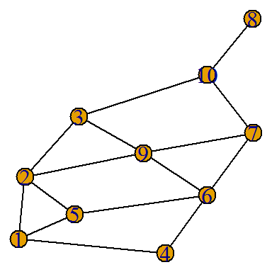

```r
max(sapply(cliques(g),length)) #chomatic number >= 3
```

```
## [1] 3
```

```r
max(degree(g)) + 1 #chomatic number <= 5
```

```
## [1] 5
```

## Algoritmo DSatur

Algortimo similar ao *GREEDY*.  
**Diferença:** Geração da ordem dos vértices prioriza vértices com menor número de opções de cores disponíveis.

- O **grau de saturação** de um vértice \(v \in V\) tal que \(c(v)=NULL\) é dado por: \(sat(v)=||c(u):u \in \Gamma(v) \wedge c(u) \neq NULL||\).

Em cada iteração do algoritmo escolhe-se o vértice, não colorido, com maior grau de saturação. Em caso de igualdade, escolhe-se o de maior grau. Em caso de novo empate, sorteia-se aleatoriamente.

Inicialmente, todos os vértices tem \(sat = 0\), então começa-se com o vértice de maior grau.

### Passo a Passo:

[figure not shown]

### R: igraph package - Algoritmo DSatur

```r
vertex.color.dsatur <- function(g){
  grps <- list()
  verts <- V(g)
  d.satur <- rep(0,times=length(verts))
  while(length(verts)!=0){
    d <- data.frame(as.vector(verts),d.satur,deg=degree(g,verts))
    seq <- d[order(d$d.satur,d$deg,decreasing=T),1]
    for(i in seq){
      if(length(grps)==0){grps[[1]]<-i;verts<-verts[verts!=i]}else{
        for(j in 1:length(grps)){
          if(sum(grps[[j]]%in%neighbors(g,i))==0){grps[[j]]<- c(grps[[j]],i);verts<-verts[verts!=i];break}
        }
        if(sum(i%in%unlist(grps))==0){grps[[(length(grps)+1)]] <- i;verts<-verts[verts!=i]}
      }
    }
    d.satur <- c()
    for(i in verts){
      s <- 0
      for(j in grps){
        if(sum(j%in%neighbors(g,i))>0){s <- s+1}}
      d.satur <- c(d.satur,s)}}
  grps2 <- list(no._de_grupos=length(grps),grupos=grps)
  return(grps2)}
```

## Algoritmo RLF

**Estratégia Diferente:** Forma-se uma classe de cor por vez.  
No i-ésimo passo a classe de cor \(S_i\) é construída: inicialmente um vértice \(v\) é selecionado e adicionado à classe de cor. Então, dentre os vértices restantes que podem ser adicionado à classe, escolhe-se o próximo vértice. O algoritmo prossegue até não se ter mais opções de vértices. No próximo passo a classe \(S_{i+1}\) é construída.

- A escolha dos vértices quando se tem mais de uma opção disponível é feita aleatoriamente.

### Passo a Passo:

[figure not shown]

### R: igraph package - Algoritmo RLF

```r
vertex.color.RLF <- function(g){
  grps <- list()
  while(sum(V(g)%in%unlist(grps))!=length(V(g))){
    X <- V(g)[!V(g)%in%unlist(grps)]
    grp.new <- c()
    while(length(X)>0){
      if(length(X)==1){v<-X}else{v <- sample(X,1,replace=F)}
      grp.new <- c(grp.new,v)
      X <- X[X!=v]
      X <- X[!X%in%neighbors(g,v)]
    }
    grps[[length(grps)+1]] <- grp.new
  }
  grps2 <- list(no._de_grupos=length(grps),grupos=grps)
  return(grps2)
}
```

## Exemplo

## Colorindo o Brasil

[figure not shown]

### Grafo do Brasil

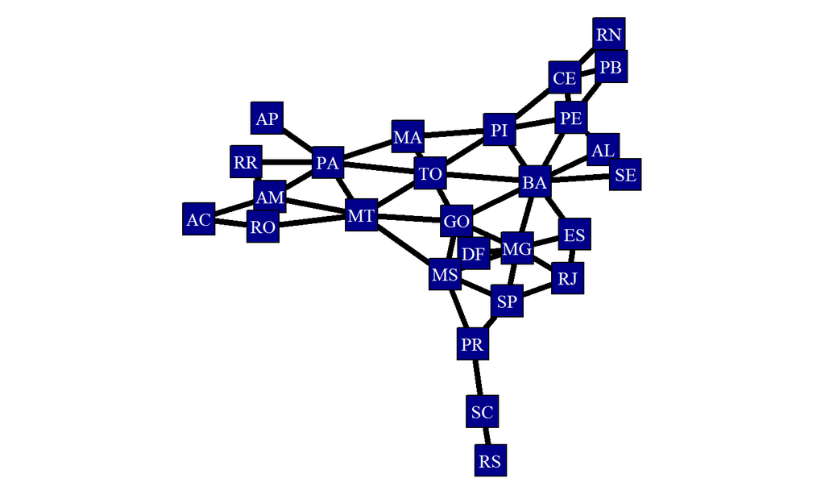

### Limites para \(\chi(G)\)

```r
c(lower=max(sapply(cliques(brasil_map),length)), upper=max(degree(brasil_map)) + 1)
```

```
## lower upper
##     3     9
```

\(3 \leq \chi(G) \leq 9\)

### GREEDY

```r
brasil.greedy <- vertex.color.greedy(brasil_map, sample(V(brasil_map)))
brasil.greedy
```

```
## $no._de_grupos
## [1] 5
##
## $grupos
## $grupos[[1]]
##  [1]  8 15 22 20 24  2  3 27  7 13
##
## $grupos[[2]]
## [1] 10  5  4 11 25 21 26 23
##
## $grupos[[3]]
## [1] 14  6 17 18  9
##
## $grupos[[4]]
## [1] 12  1 16
##
## $grupos[[5]]
## [1] 19
```

### DSatur

```r
brasil.dsatur <- vertex.color.dsatur(brasil_map)
brasil.dsatur
```

```
## $no._de_grupos
## [1] 4
##
## $grupos
## $grupos[[1]]
## [1] 12  5 15 18  4 25 13 26
##
## $grupos[[2]]
##  [1] 14  6 11 17 21 22  2  3  7 27
##
## $grupos[[3]]
## [1]  8  1 19 16 24 20 23
##
## $grupos[[4]]
## [1] 10  9
```

### RLF

```r
brasil.rlf <- vertex.color.RLF(brasil_map)
brasil.rlf
```

```
## $no._de_grupos
## [1] 4
##
## $grupos
## $grupos[[1]]
## MA AP CE AC SP DF SC BA MT RR
##  9  7 18  2 16 13 26 12  6  3
##
## $grupos[[2]]
## PA PB RJ PI MS RS SE RO
##  5 21 25 11 15 27 23  4
##
## $grupos[[3]]
## TO PR PE RN MG AM
##  8 17 19 20 14  1
##
## $grupos[[4]]
## ES AL GO
## 24 22 10
```

### GREEDY Alternativo

```r
brasil.greedy2 <- vertex.color.greedy.2(brasil_map, sample(V(brasil_map)), times=10)
brasil.greedy2
```

```
## $no._de_grupos
## [1] 4
##
## $grupos
## $grupos[[1]]
## [1]  9 16  1 13 12 26  7 18
##
## $grupos[[2]]
## [1] 10 11 25  2 27 17  5 22 21
##
## $grupos[[3]]
## [1] 23 20 19 14  3  6
##
## $grupos[[4]]
## [1]  4 24  8 15
```

### Pacote 'tmaptools' - GREEDY

```r
brasil_map2 <- as_adj_list(brasil_map)
brasil.tmap <- map_coloring(brasil_map2, algorithm = "greedy", minimize = TRUE)
brasil.tmap
```

```
##  [1] 3 2 2 1 1 2 2 3 4 4 2 1 1 2 1 3 2 1 3 3 2 2 3 3 1 1 2
```

```r
max(brasil.tmap)
```

```
## [1] 4
```

### Coloração RLF

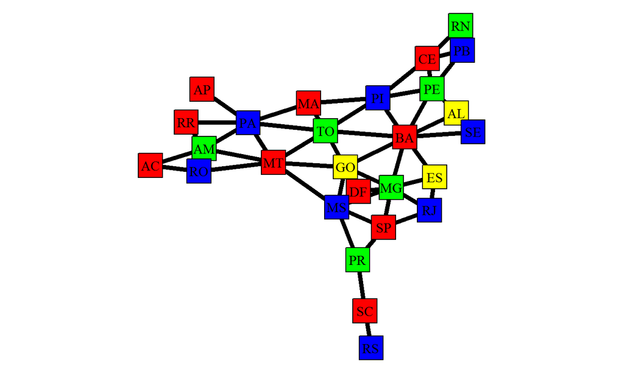

### Coloração 'tmaptools'

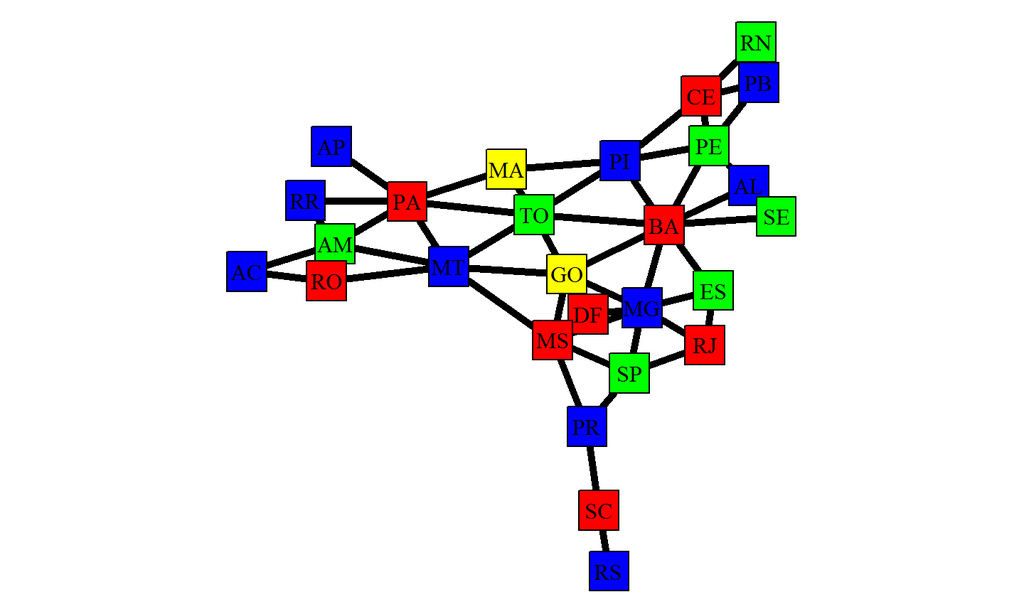

## Comparação dos Algoritmos

## Comparação Empírica dos Algoritmos em C++

Gerou-se aleatoriamente grafos variando o número de vértices e a densidade. Observou-se a performance dos algortimos tanto em custo computacional quanto no número de cores da solução.

- Em geral, para grafos com grande número de vértices, o algoritmo *RLF* produz resultados com menor número de cores. Contudo, é o mais custoso computacionalmente.
- O algoritmo *DSatur* produz, em geral, melhores soluções do que o *GREEDY*, e o custo computacional de ambos foi equivalente.

[figure not shown]

*Sumário dos resultados produzidos pelos 3 algoritmos ao se gerar 50 grafos para diferentes tamanhos e densidade de 0.5.*

## Compração Empírica dos Algoritmos em R

[figure not shown]

## Outros Algoritmos

## Algoritmos mais Avançados

### Algoritmos Exatos:

Sempre obtêm solução ótima (sem tempo limite de execução ou outro critério de parada).

### Algoritmos heurísticos e meta-heurísticos:

- São adaptáveis a diferentes problemas.
- Frequentemente apresentam bons resultados para grafos com grande número de vértices.

\(\Rightarrow\) São apresentados diversos algoritmos mais complexos que adotam diferentes estratégias para a resolução de problemas de coloração dos grafos.

\(\Rightarrow\) São discutidas aplicações e extensões do problema. Além de problemas práticos do mundo real.

## Referências:

- LEWIS, R.M.R. **A Guide to Graph Colouring: Algorithms and Applications**. Springer International Publishing Switzerland, 2016.
- CRAN. **Igraph**: Network Analysis and Visualization
- CRAN. **tmaptools**: Thematic Map Tools
- CRAN. **BiocManager**: Access the Bioconductor Project Package Repository
- Bioconductor. **RBGL**: An interface to the BOOST graph library
- Bioconductor. **Graph**: A package to handle graph data structures

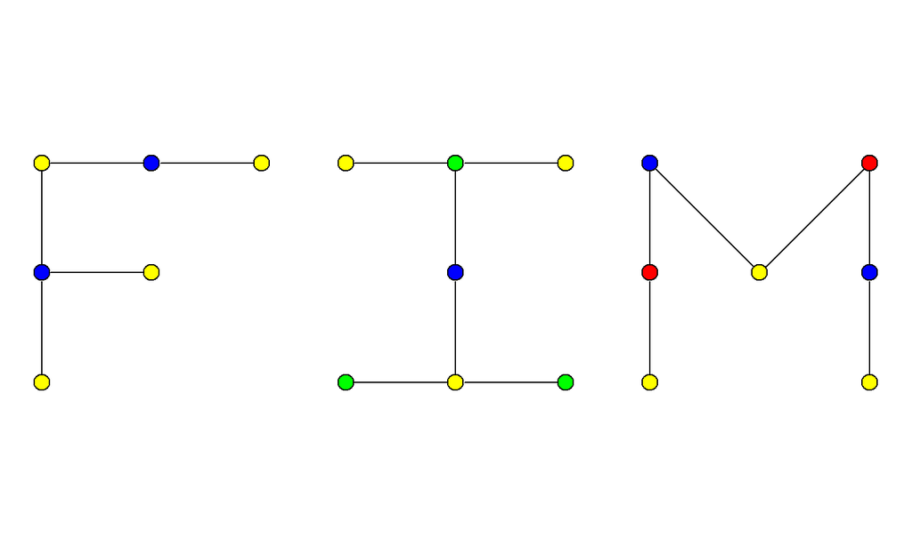